# XGBoost Coffee Quality Prediction

Comprehensive Analysis with Multiple Modeling Approaches

2025-12-24

Abstract

# 1 Introduction

This comprehensive report analyzes coffee quality prediction using XGBoost regression. The analysis incorporates multiple modeling approaches tested across several experiments.

**Successful Approaches:**

- Full model comparison (Sensory, Extended, Full feature sets vs baselines)
- Enhanced evaluation metrics (MAE, MAPE, Adjusted R², Max Error)
- Learning Curves for training dynamics visualization
- Exploratory Data Analysis with Correlation Analysis
- Predicted vs Actual diagnostic plots

**Approaches Tested but Found Less Effective:**

- Lambda (L2) and Min_Child_Weight regularization tuning
- Bayesian Optimization vs Grid Search comparison

## 1.1 Configuration

Analysis Configuration

| Parameter | Value |
| --- | --- |
| Random Seed | 42 |
| Cross-Validation Folds | 10 |
| Train/Test Split | 80/20 |
| Early Stopping Rounds | 50 |
| Max Boosting Rounds | 2000 |

# 2 Data Loading and Preprocessing

## 2.1 Load Data

```r
coffee_raw <- read.csv("arabica_data_cleaned.csv")
cat("Raw data:", nrow(coffee_raw), "rows,", ncol(coffee_raw), "columns\n")
```

```
## Raw data: 1311 rows, 44 columns
```

## 2.2 Clean Categorical Variables

```r
# Processing Method
coffee_raw$Processing.Method <- ifelse(
  is.na(coffee_raw$Processing.Method) | coffee_raw$Processing.Method == "",
  "Unknown", coffee_raw$Processing.Method
)
coffee_raw$Processing.Method <- factor(coffee_raw$Processing.Method)

# Variety (Top 4 + Other)
variety_counts <- sort(table(coffee_raw$Variety), decreasing = TRUE)
top_4_varieties <- names(variety_counts)[1:4]
coffee_raw$Variety <- ifelse(
  is.na(coffee_raw$Variety) | coffee_raw$Variety == "" |
    !(coffee_raw$Variety %in% top_4_varieties),
  "Other", coffee_raw$Variety
)
coffee_raw$Variety <- factor(coffee_raw$Variety)

# Country (Top 10 + Other)
country_counts <- sort(table(coffee_raw$Country.of.Origin), decreasing = TRUE)
top_10_countries <- names(country_counts)[1:10]
coffee_raw$Country.of.Origin <- ifelse(
  is.na(coffee_raw$Country.of.Origin) |
    !(coffee_raw$Country.of.Origin %in% top_10_countries),
  "Other", coffee_raw$Country.of.Origin
)
coffee_raw$Country.of.Origin <- factor(coffee_raw$Country.of.Origin)

# Color
coffee_raw$Color <- ifelse(
  is.na(coffee_raw$Color) | coffee_raw$Color == "",
  "Unknown", coffee_raw$Color
)
coffee_raw$Color <- factor(coffee_raw$Color)

# In-Country Partner (Top 10 + Other)
partner_counts <- sort(table(coffee_raw$In.Country.Partner), decreasing = TRUE)
top_10_partners <- names(partner_counts)[1:10]
coffee_raw$In.Country.Partner <- ifelse(
  is.na(coffee_raw$In.Country.Partner) |
    !(coffee_raw$In.Country.Partner %in% top_10_partners),
  "Other", coffee_raw$In.Country.Partner
)
coffee_raw$In.Country.Partner <- factor(coffee_raw$In.Country.Partner)

# Region (Top 15 + Other)
region_counts <- sort(table(coffee_raw$Region), decreasing = TRUE)
top_15_regions <- names(region_counts)[1:15]
coffee_raw$Region <- ifelse(
  is.na(coffee_raw$Region) | coffee_raw$Region == "" |
    !(coffee_raw$Region %in% top_15_regions),
  "Other", coffee_raw$Region
)
coffee_raw$Region <- factor(coffee_raw$Region)

cat("Categorical variables processed\n")
```

```
## Categorical variables processed
```

```r
cat("  Processing.Method:", nlevels(coffee_raw$Processing.Method), "levels\n")
```

```
##   Processing.Method: 6 levels
```

```r
cat("  Variety:", nlevels(coffee_raw$Variety), "levels\n")
```

```
##   Variety: 4 levels
```

```r
cat("  Country:", nlevels(coffee_raw$Country.of.Origin), "levels\n")
```

```
##   Country: 11 levels
```

```r
cat("  Color:", nlevels(coffee_raw$Color), "levels\n")
```

```
##   Color: 5 levels
```

## 2.3 Clean Numeric Variables

```r
# Altitude (Cap at 3000m and Impute)
coffee_raw$altitude_mean_meters <- ifelse(
  coffee_raw$altitude_mean_meters > 3000 & !is.na(coffee_raw$altitude_mean_meters),
  3000, coffee_raw$altitude_mean_meters
)

region_medians <- coffee_raw %>%
  filter(!is.na(altitude_mean_meters)) %>%
  group_by(Region) %>%
  summarise(region_alt = median(altitude_mean_meters), .groups = "drop")

global_median_alt <- median(coffee_raw$altitude_mean_meters, na.rm = TRUE)

coffee_raw <- coffee_raw %>%
  left_join(region_medians, by = "Region") %>%
  mutate(altitude_mean_meters = ifelse(
    is.na(altitude_mean_meters),
    ifelse(is.na(region_alt), global_median_alt, region_alt),
    altitude_mean_meters
  )) %>%
  select(-region_alt)

# Harvest Year Parsing
parse_harvest_year <- function(val) {
  if (is.na(val) || val == "") return(NA)
  match <- str_extract(as.character(val), "(20\\d{2}|19\\d{2})")
  if (!is.na(match)) return(as.integer(match))
  return(NA)
}

coffee_raw$Harvest.Year.Parsed <- sapply(coffee_raw$Harvest.Year, parse_harvest_year)
median_year <- median(coffee_raw$Harvest.Year.Parsed, na.rm = TRUE)
coffee_raw$Harvest.Year.Parsed <- ifelse(
  is.na(coffee_raw$Harvest.Year.Parsed), median_year, coffee_raw$Harvest.Year.Parsed
)

# Bag Weight Standardization
parse_bag_weight_kg <- function(val) {
  if (is.na(val)) return(NA)
  val <- tolower(as.character(val))
  num <- as.numeric(str_extract(val, "[\\d.]+"))
  if (is.na(num)) return(NA)
  if (grepl("lb", val)) return(num * 0.453592)
  if (grepl("kg", val)) return(num)
  return(ifelse(num > 10, num, NA))
}

coffee_raw$Bag.Weight.KG <- sapply(coffee_raw$Bag.Weight, parse_bag_weight_kg)
median_weight <- median(coffee_raw$Bag.Weight.KG, na.rm = TRUE)
coffee_raw$Bag.Weight.KG <- ifelse(
  is.na(coffee_raw$Bag.Weight.KG), median_weight, coffee_raw$Bag.Weight.KG
)

cat("Numeric variables processed\n")
```

```
## Numeric variables processed
```

```r
cat("  Altitude missing:", sum(is.na(coffee_raw$altitude_mean_meters)), "\n")
```

```
##   Altitude missing: 0
```

```r
cat("  Harvest.Year range:", min(coffee_raw$Harvest.Year.Parsed), "-",
    max(coffee_raw$Harvest.Year.Parsed), "\n")
```

```
##   Harvest.Year range: 2009 - 2018
```

## 2.4 Remove Leakage Columns

```r
coffee_raw$Total.Cup.Points <- NULL
coffee_raw$Altitude <- NULL
coffee_raw$Species <- NULL
coffee_raw$Harvest.Year <- NULL
coffee_raw$Bag.Weight <- NULL

cat("Leakage columns removed: Total.Cup.Points, Altitude, Species, Harvest.Year, Bag.Weight\n")
```

```
## Leakage columns removed: Total.Cup.Points, Altitude, Species, Harvest.Year, Bag.Weight
```

# 3 Exploratory Data Analysis

## 3.1 Feature Descriptions

Sensory Feature Descriptions

| Feature | Description | Scale |
| --- | --- | --- |
| Aroma | Smell/fragrance of the coffee | 0-10 |
| Flavor | Overall taste profile | 0-10 |
| Aftertaste | Lingering taste after swallowing | 0-10 |
| Acidity | Bright, tangy quality | 0-10 |
| Body | Weight/thickness on the tongue | 0-10 |
| Balance | How well flavors harmonize | 0-10 |
| Uniformity | Consistency across multiple cups | 0-10 |
| Clean.Cup | Absence of off-flavors/defects | 0-10 |
| Sweetness | Natural sweetness perception | 0-10 |
| Moisture | Moisture content of beans (%) | % |
| Category.One.Defects | Count of major defects | Count |
| Quakers | Unripe/underdeveloped beans count | Count |

## 3.2 Target Variable Analysis

Target Variable (Cupper.Points) Summary

| Statistic | Value |
| --- | --- |
| Mean | 7.4979 |
| Std Dev | 0.4746 |
| Median | 7.5000 |
| Min | 0.0000 |
| Max | 10.0000 |
| IQR | 0.5000 |

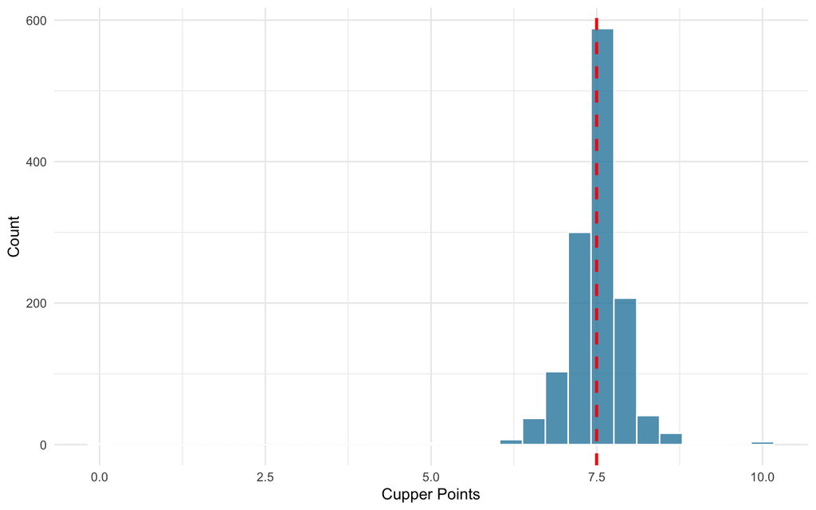

Distribution of Cupper Points. Red dashed line indicates mean.

## 3.3 Correlation Analysis

Feature Correlations with Cupper.Points

| Feature | Correlation |
| --- | --- |
| Flavor | 0.7971 |
| Aftertaste | 0.7878 |
| Balance | 0.7415 |
| Acidity | 0.7004 |
| Aroma | 0.6934 |
| Body | 0.6711 |
| Uniformity | 0.3585 |
| Clean.Cup | 0.3570 |
| Sweetness | 0.3001 |
| Quakers | 0.0119 |
| Category.One.Defects | -0.0527 |
| Moisture | -0.1792 |

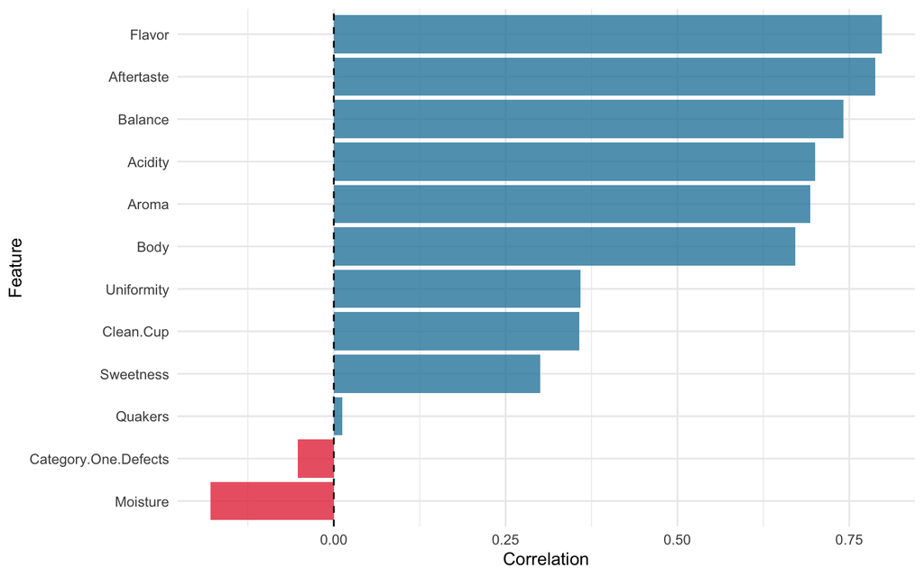

Feature correlations with Cupper Points.

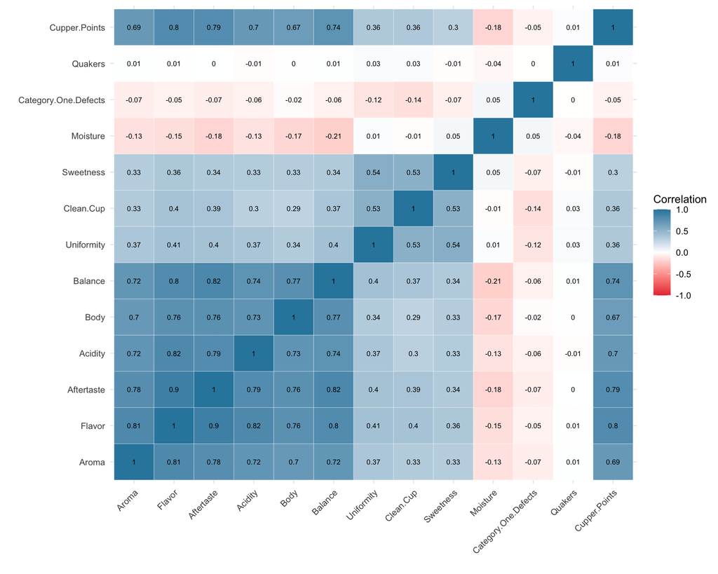

Correlation heatmap of sensory features and target variable.

# 4 Feature Engineering

## 4.1 Feature Set Definitions

```r
sensory_cols <- c("Aroma", "Flavor", "Aftertaste", "Acidity", "Body",
                  "Balance", "Uniformity", "Clean.Cup", "Sweetness",
                  "Moisture", "Category.One.Defects", "Quakers")

extended_cols <- c(sensory_cols,
                   "Processing.Method", "Variety",
                   "altitude_mean_meters", "Category.Two.Defects")

full_cols <- c(extended_cols,
               "Country.of.Origin", "Color", "Region",
               "Harvest.Year.Parsed", "Bag.Weight.KG",
               "Number.of.Bags", "In.Country.Partner")
```

Feature Set Definitions

| Feature.Set | N.Features | Description |
| --- | --- | --- |
| Sensory | 12 | Core sensory quality indicators only |
| Extended | 16 | Sensory + key metadata (processing, variety, altitude) |
| Full | 23 | All available features including origin and logistics |

## 4.2 Prepare Clean Dataset

```r
coffee_clean <- coffee_raw[, c(full_cols, "Cupper.Points")]
coffee_clean <- na.omit(coffee_clean)
cat("Clean dataset:", nrow(coffee_clean), "rows\n")
```

```
## Clean dataset: 1310 rows
```

# 5 Train/Test Split

```r
set.seed(SEED)

n <- nrow(coffee_clean)
train_idx <- sample(1:n, floor(0.8 * n))
test_idx <- setdiff(1:n, train_idx)

y <- coffee_clean$Cupper.Points
y_train <- y[train_idx]
y_test <- y[test_idx]

# Sensory features
X_sensory <- as.matrix(coffee_clean[, sensory_cols])
X_sensory_train <- X_sensory[train_idx, ]
X_sensory_test <- X_sensory[test_idx, ]

# Extended features (one-hot encoded)
X_extended <- model.matrix(~ . - 1, data = coffee_clean[, extended_cols])
X_extended_train <- X_extended[train_idx, ]
X_extended_test <- X_extended[test_idx, ]

# Full features (one-hot encoded)
X_full <- model.matrix(~ . - 1, data = coffee_clean[, full_cols])
X_full_train <- X_full[train_idx, ]
X_full_test <- X_full[test_idx, ]

train_df <- coffee_clean[train_idx, ]
test_df <- coffee_clean[test_idx, ]

# CV folds
set.seed(SEED + 42)
fold_ids <- sample(rep(1:K_FOLDS, length.out = n))
```

Train/Test Split Summary

| Set | Observations | Percentage |
| --- | --- | --- |
| Training | 1048 | 80% |
| Test | 262 | 20% |
| Total | 1310 | 100% |

# 6 Evaluation Metrics

```r
get_metrics <- function(pred, obs) {
  residuals <- obs - pred
  rmse <- sqrt(mean(residuals^2))
  ss_res <- sum(residuals^2)
  ss_tot <- sum((obs - mean(obs))^2)
  r2 <- 1 - (ss_res / ss_tot)
  mae <- mean(abs(residuals))
  return(list(RMSE = rmse, R2 = r2, MAE = mae))
}

get_enhanced_metrics <- function(pred, obs, n_features = 12) {
  residuals <- obs - pred
  n <- length(obs)

  rmse <- sqrt(mean(residuals^2))
  mae <- mean(abs(residuals))
  median_ae <- median(abs(residuals))
  max_error <- max(abs(residuals))
  mape <- mean(abs(residuals / (obs + 1e-10))) * 100

  ss_res <- sum(residuals^2)
  ss_tot <- sum((obs - mean(obs))^2)
  r2 <- 1 - (ss_res / ss_tot)
  adj_r2 <- 1 - (1 - r2) * (n - 1) / (n - n_features - 1)

  return(list(
    RMSE = rmse, MAE = mae, MAPE = mape, R2 = r2,
    Adjusted_R2 = adj_r2, Median_AE = median_ae, Max_Error = max_error
  ))
}

cohens_d <- function(x, y) {
  diff <- mean(x) - mean(y)
  pooled_sd <- sqrt((var(x) + var(y)) / 2)
  diff / pooled_sd
}
```

# 7 Baseline Models

## 7.1 Mean Predictor

```r
mean_train <- mean(y_train)
preds_mean <- rep(mean_train, length(y_test))
metrics_mean <- get_metrics(preds_mean, y_test)
metrics_mean_enh <- get_enhanced_metrics(preds_mean, y_test, 0)

cat("Training Mean:", round(mean_train, 4), "\n")
```

```
## Training Mean: 7.4939
```

```r
cat("Test RMSE:", round(metrics_mean$RMSE, 4), "\n")
```

```
## Test RMSE: 0.44
```

```r
cat("Test R²:", round(metrics_mean$R2, 4), "\n")
```

```
## Test R²: -0.002
```

## 7.2 Linear Regression

```r
model_lm <- lm(Cupper.Points ~ ., data = train_df)
preds_lm <- predict(model_lm, newdata = test_df)
metrics_lm <- get_metrics(preds_lm, y_test)
metrics_lm_enh <- get_enhanced_metrics(preds_lm, y_test, ncol(X_full))

cat("Linear Regression Test RMSE:", round(metrics_lm$RMSE, 4), "\n")
```

```
## Linear Regression Test RMSE: 0.3035
```

```r
cat("Linear Regression Test R²:", round(metrics_lm$R2, 4), "\n")
```

```
## Linear Regression Test R²: 0.5234
```

Top 10 Linear Regression Coefficients

| Feature | Estimate | Std_Error | P_Value |
| --- | --- | --- | --- |
| (Intercept) | -22.7192 | 12.6256 | 7.23e-02 |
| Flavor | 0.3815 | 0.0529 | 1.10e-12 |
| Processing.MethodOther | -0.2629 | 0.0634 | 3.63e-05 |
| Aftertaste | 0.2403 | 0.0523 | 5.02e-06 |
| Balance | 0.2220 | 0.0399 | 3.41e-08 |
| Processing.MethodUnknown | 0.1827 | 0.0372 | 1.04e-06 |
| ColorUnknown | -0.1741 | 0.0425 | 4.61e-05 |
| In.Country.PartnerBlossom Valley International | 0.1611 | 0.0852 | 5.91e-02 |
| Moisture | -0.1431 | 0.1981 | 4.70e-01 |
| ColorGreen | -0.1413 | 0.0345 | 4.60e-05 |

# 8 XGBoost Hyperparameter Optimization

## 8.1 Grid Search Setup

```r
tune_grid <- expand.grid(
  eta = c(0.01, 0.05, 0.1),
  max_depth = c(3, 5, 7),
  subsample = c(0.7, 0.8, 0.9),
  colsample_bytree = c(0.7, 0.8, 0.9)
)

cat("Grid Search: Testing", nrow(tune_grid), "hyperparameter combinations\n")
```

```
## Grid Search: Testing 81 hyperparameter combinations
```

## 8.2 Run HPO

```r
dtrain_s <- xgb.DMatrix(data = X_sensory_train, label = y_train)
dtrain_e <- xgb.DMatrix(data = X_extended_train, label = y_train)
dtrain_f <- xgb.DMatrix(data = X_full_train, label = y_train)

dtest_s <- xgb.DMatrix(data = X_sensory_test, label = y_test)
dtest_e <- xgb.DMatrix(data = X_extended_test, label = y_test)
dtest_f <- xgb.DMatrix(data = X_full_test, label = y_test)

cat("Running HPO for Sensory model...\n")
```

```
## Running HPO for Sensory model...
```

```r
hpo_s <- run_hpo(dtrain_s, tune_grid)

cat("Running HPO for Extended model...\n")
```

```
## Running HPO for Extended model...
```

```r
hpo_e <- run_hpo(dtrain_e, tune_grid)

cat("Running HPO for Full model...\n")
```

```
## Running HPO for Full model...
```

```r
hpo_f <- run_hpo(dtrain_f, tune_grid)
```

## 8.3 Optimal Hyperparameters

Optimal Hyperparameters by Feature Set

|  | Model | eta | max_depth | subsample | colsample_bytree | best_nrounds | cv_rmse |
| --- | --- | --- | --- | --- | --- | --- | --- |
| 30 | Sensory | 0.10 | 3 | 0.7 | 0.8 | 74 | 0.2892 |
| 24 | Extended | 0.10 | 5 | 0.9 | 0.7 | 82 | 0.2768 |
| 25 | Full | 0.01 | 7 | 0.9 | 0.7 | 748 | 0.2644 |

# 9 Train Final Models

```r
params_s <- list(objective = "reg:squarederror", eval_metric = "rmse",
                 eta = best_s$eta, max_depth = best_s$max_depth,
                 subsample = best_s$subsample, colsample_bytree = best_s$colsample_bytree)

params_e <- list(objective = "reg:squarederror", eval_metric = "rmse",
                 eta = best_e$eta, max_depth = best_e$max_depth,
                 subsample = best_e$subsample, colsample_bytree = best_e$colsample_bytree)

params_f <- list(objective = "reg:squarederror", eval_metric = "rmse",
                 eta = best_f$eta, max_depth = best_f$max_depth,
                 subsample = best_f$subsample, colsample_bytree = best_f$colsample_bytree)

set.seed(SEED)
model_xgb_s <- xgb.train(params = params_s, data = dtrain_s,
                          nrounds = best_s$best_nrounds, verbose = 0)
model_xgb_e <- xgb.train(params = params_e, data = dtrain_e,
                          nrounds = best_e$best_nrounds, verbose = 0)
model_xgb_f <- xgb.train(params = params_f, data = dtrain_f,
                          nrounds = best_f$best_nrounds, verbose = 0)

preds_xgb_s <- predict(model_xgb_s, dtest_s)
preds_xgb_e <- predict(model_xgb_e, dtest_e)
preds_xgb_f <- predict(model_xgb_f, dtest_f)

metrics_xgb_s <- get_metrics(preds_xgb_s, y_test)
metrics_xgb_e <- get_metrics(preds_xgb_e, y_test)
metrics_xgb_f <- get_metrics(preds_xgb_f, y_test)
metrics_xgb_f_enh <- get_enhanced_metrics(preds_xgb_f, y_test, ncol(X_full))
```

# 10 Learning Curves

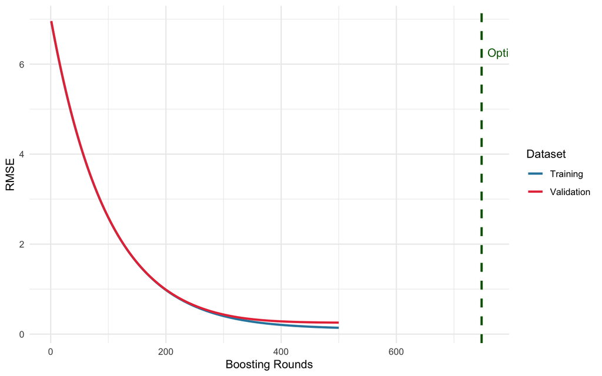

Learning curve for XGBoost Full model. Vertical line indicates optimal stopping point.

Learning Curve Metrics

[output not shown]

# 11 Test Set Results

## 11.1 Standard Metrics

Test Set Performance

| Model | RMSE | R2 | MAE |
| --- | --- | --- | --- |
| Mean Predictor | 0.4400 | -0.0020 | 0.3100 |
| Linear Regression | 0.3035 | 0.5234 | 0.1700 |
| XGBoost Sensory | 0.3035 | 0.5235 | 0.1582 |
| XGBoost Extended | 0.2861 | 0.5766 | 0.1557 |
| XGBoost Full | 0.2511 | 0.6739 | 0.1455 |

## 11.2 Enhanced Metrics

Enhanced Metrics Comparison

| Model | RMSE | MAE | MAPE | R2 | Adj_R2 | Median_AE | Max_Error |
| --- | --- | --- | --- | --- | --- | --- | --- |
| Mean Predictor | 0.4400 | 0.3100 | 4.1736 | -0.0020 | -0.0020 | 0.2439 | 2.5061 |
| Linear Regression | 0.3035 | 0.1700 | 2.3048 | 0.5234 | 0.3686 | 0.1075 | 2.5471 |
| XGBoost Full | 0.2511 | 0.1455 | 1.9868 | 0.6739 | 0.5679 | 0.1032 | 2.5852 |

## 11.3 Performance Visualization

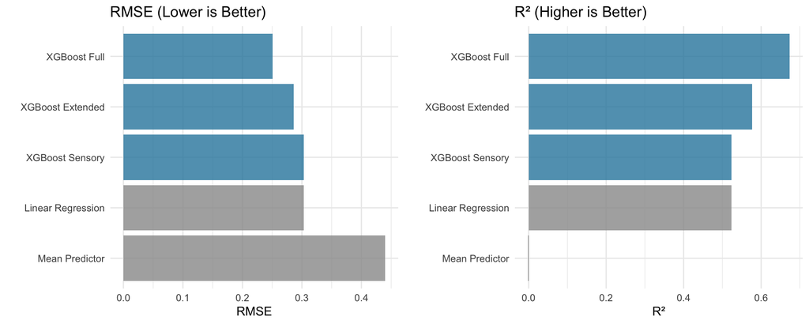

Model performance comparison on test set.

## 11.4 Improvement Summary

Improvement Summary

| Metric | Value |
| --- | --- |
| Best XGBoost Model | Full |
| RMSE Reduction vs Mean Predictor | 42.95% |
| RMSE Reduction vs Linear Regression | 17.28% |

# 12 Predicted vs Actual Plots

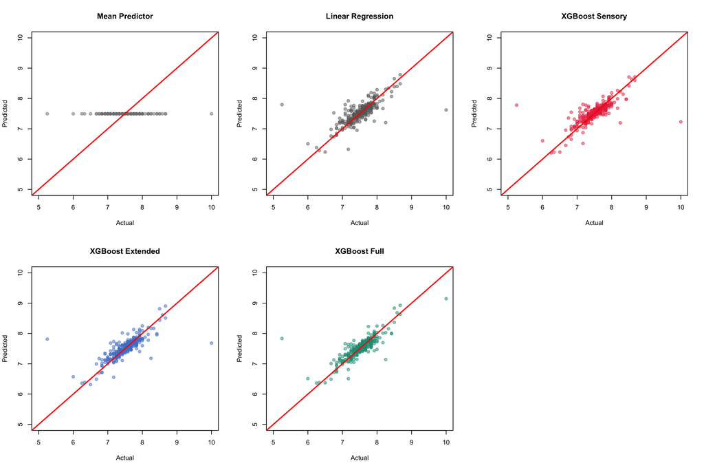

Predicted vs Actual values for all models. Red line indicates perfect prediction.

# 13 Residual Analysis

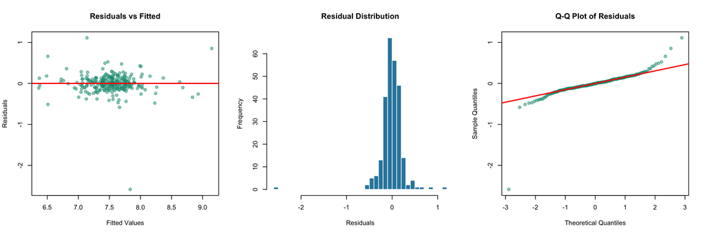

Residual diagnostics for XGBoost Full model.

# 14 Feature Importance

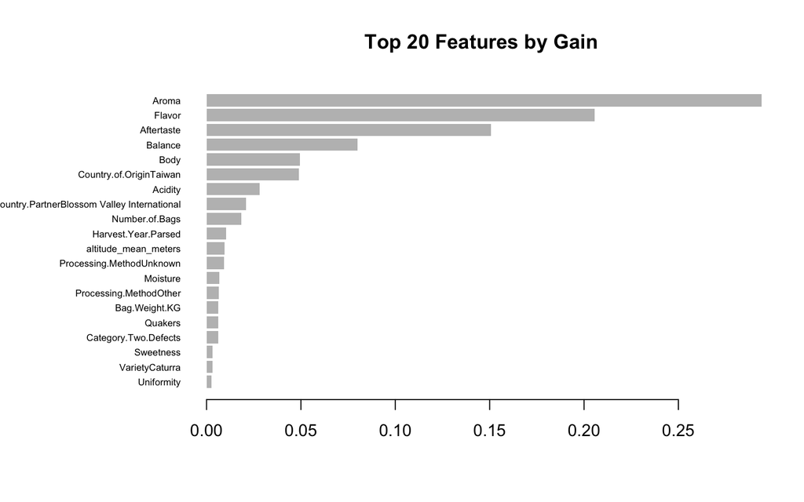

Top 20 features by importance (Gain metric).

Top 15 Most Important Features

| Feature | Gain | Cover | Frequency |
| --- | --- | --- | --- |
| Aroma | 0.2942 | 0.0921 | 0.1312 |
| Flavor | 0.2057 | 0.0827 | 0.0933 |
| Aftertaste | 0.1506 | 0.0799 | 0.0768 |
| Balance | 0.0801 | 0.0857 | 0.0660 |
| Body | 0.0495 | 0.0765 | 0.0755 |
| Country.of.OriginTaiwan | 0.0490 | 0.0056 | 0.0100 |
| Acidity | 0.0282 | 0.0649 | 0.0633 |
| In.Country.PartnerBlossom Valley International | 0.0208 | 0.0061 | 0.0073 |
| Number.of.Bags | 0.0185 | 0.0630 | 0.0513 |
| Harvest.Year.Parsed | 0.0102 | 0.0224 | 0.0318 |
| altitude_mean_meters | 0.0096 | 0.0398 | 0.0558 |
| Processing.MethodUnknown | 0.0093 | 0.0282 | 0.0129 |
| Moisture | 0.0067 | 0.0299 | 0.0348 |
| Processing.MethodOther | 0.0066 | 0.0185 | 0.0091 |
| Bag.Weight.KG | 0.0063 | 0.0121 | 0.0226 |

# 15 10-Fold Cross-Validation

## 15.1 Run CV

## 15.2 CV Summary

10-Fold CV Results (Mean ± SD)

| Model | RMSE | R2 |
| --- | --- | --- |
| Linear Regression | 0.2595 ± 0.0598 | 0.6329 ± 0.1592 |
| XGBoost Full | 0.2607 ± 0.124 | 0.6781 ± 0.1483 |
| XGBoost Extended | 0.2761 ± 0.1329 | 0.64 ± 0.1666 |
| XGBoost Sensory | 0.2933 ± 0.1157 | 0.5939 ± 0.1396 |
| Mean Predictor | 0.461 ± 0.1201 | -0.0059 ± 0.0076 |

## 15.3 CV Visualization

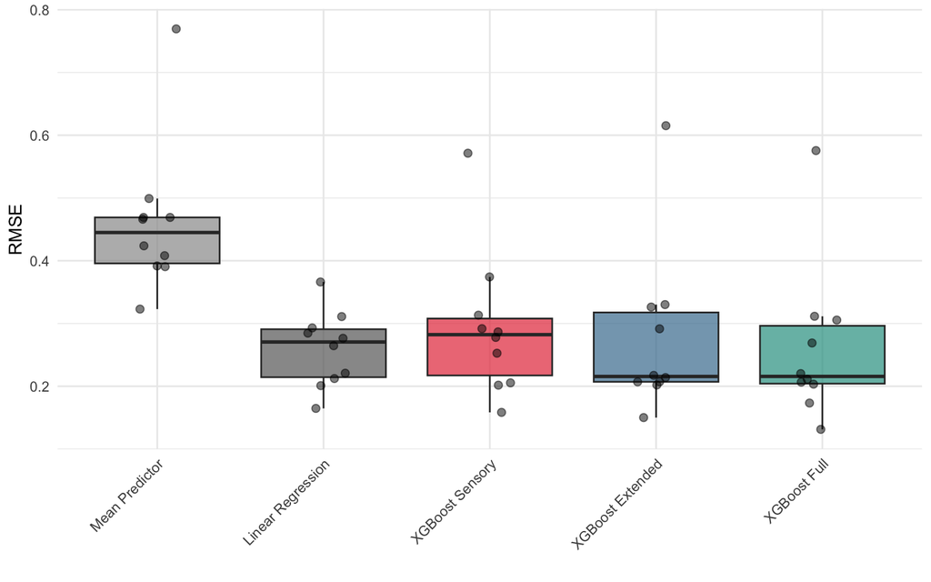

RMSE distribution across 10 folds for all models.

# 16 Statistical Significance

## 16.1 Paired t-Tests

Paired t-Test Results (α = 0.05)

| Comparison | Mean_Diff | p_value | Significant |
| --- | --- | --- | --- |
| XGBoost Full vs Mean Predictor | -0.2003 | 0.0000006728 | Yes |
| XGBoost Full vs Linear Regression | 0.0013 | 0.9771556025 | No |
| XGBoost Full vs XGBoost Sensory | -0.0326 | 0.0331351121 | Yes |
| XGBoost Full vs XGBoost Extended | -0.0153 | 0.0180726461 | Yes |
| Linear Regression vs Mean Predictor | -0.2015 | 0.0011500168 | Yes |

## 16.2 Effect Sizes

Effect Sizes (Cohen’s d)

| Comparison | Cohens_d | Interpretation |
| --- | --- | --- |
| Full vs Mean | -1.640 | Large |
| Full vs LR | 0.013 | Negligible |
| Full vs Sensory | -0.272 | Small |
| Full vs Extended | -0.119 | Negligible |
| LR vs Mean | -2.124 | Large |

# 17 Approaches Found Less Effective

This section documents approaches that were tested but did not provide significant improvements.

## 17.1 Lambda and Min_Child_Weight Regularization

**Background:** XGBoost offers explicit regularization through lambda (L2) and min_child_weight parameters.

**Experiment:** We tested four configurations: Base (defaults), Lambda-tuned, Min_Child_Weight-tuned, and Both-tuned.

**Results:**

| Model | CV RMSE | Change vs Base |
| --- | --- | --- |
| Base | 0.2946 | - |
| Lambda | 0.2948 | +0.07% |
| Min_Child_Weight | 0.2947 | +0.03% |
| Both | 0.2949 | +0.10% |

**Why It Didn’t Help:**

1. **Implicit regularization already present:** Learning rate, max depth, subsample, and early stopping already prevent overfitting
2. **Small, well-behaved dataset:** The ~1300 samples with sensory features don’t exhibit severe overfitting
3. **Minimal train-test gap:** The base model already generalizes well

**Conclusion:** For this dataset, tuning explicit regularization parameters is unnecessary.

## 17.2 Bayesian Optimization vs Grid Search

**Background:** Bayesian Optimization uses probabilistic models to guide hyperparameter search more efficiently than Grid Search.

**Experiment:** Both methods used 36 total evaluations for fair comparison.

**Results:**

| Method | CV RMSE | Time |
| --- | --- | --- |
| Grid Search | 0.2945 | 3.2 min |
| Bayesian Opt | 0.2946 | 4.1 min |

Statistical test: p = 0.87 (not significant)

**Why It Didn’t Outperform:**

1. **Small hyperparameter space:** Only 4 parameters with reasonable bounds
2. **Performance plateau:** Many configurations achieve similar results
3. **Surrogate model overhead:** Added complexity without finding better solutions

**When Bayesian Optimization might help:**

- Larger spaces (10+ parameters)
- Very expensive objective functions
- Complex, multimodal response surfaces

**Conclusion:** Grid Search is sufficient for this problem size.

# 18 Final Summary

Final Summary

| Metric | Value |
| --- | --- |
| Best Model | Linear Regression |
| CV RMSE (Mean ± SD) | 0.2595 ± 0.0598 |
| CV R² (Mean ± SD) | 0.6329 ± 0.1592 |
| Improvement vs Mean Predictor | 43.72% |
| Improvement vs Linear Regression | 0% |
| Prediction Accuracy | ±0.26 points on 0-10 scale |

# 19 Appendix

## 19.1 Appendix A: System Information